# Social Phobia Experiments by Eleanor Leigh. PE analyses by Argyris

Argyris Stringaris

09/07/2022

## Overview

This is an analysis of data that Eleanor sent me yesterday (08/07/2022). They are based on her experiment described here: https://www.ncbi.nlm.nih.gov/pmc/articles/PMC7909699/

It is a within-subject experiment where adolescents with high and low social anxiety were asked to take part in a conversations with stooges (psychology students). They were instructed–in a counter-balanced fashion–to either focus on themselves and to use safety behaviours (denoted “with” in EL’s data), or not to (denoted “without”in EL’s data).

The key variables are the following:

- Prediction1Rating_Study2 -> Belief in original prediction Study 2 (0-100). For the purposes of analyses I have relablled it as expectation in code chunks below.
- Anxiety_with_Study2 -> How anxious did you feel during the WITH conversation (0-100)
- Belief_With_Study2 -> How much did your feared prediction happen (0-100) WITH
- Anxiety_WithOUT_Study2 -> How anxious did you feel during the WITHOUT conversation (0-100)
- Belief_WithOUT_Study2 -> How much did your feared prediction happen (0-100) WITHOUT

These also allow us to build prediction errors with and without safety behaviours.

**Load data**

```r
el_soph_exp_pe <- read.csv("~/Downloads/Aim1.Database Stage 2_11.2019.csv")
View(el_soph_exp_pe)
```

**Keep only Study 2 as per Eleanor’s instruction, create a PE variable, and keep necessary columns**

```r
el_soph_exp_pe <- el_soph_exp_pe %>%
filter(Study ==2) %>%
mutate (pe_with = Belief_With_Study2 - Prediction1Rating_Study2,
pe_without = Belief_WithOUT_Study2 - Prediction1Rating_Study2)
```

**Check effect of order (this was a within person cross-over experiment)**

```r
el_soph_exp_pe %>%
group_by(ConditionOrder_2) %>%
  summarise_at(c("Prediction1Rating_Study2", "Anxiety_with_Study2", "Anxiety_WithOUT_Study2", "Belief_With_Study2", "Belief_WithOUT_Study2", "pe_with", "pe_without" ),  list(avg = mean, st_dev = sd), na.rm = TRUE)
```

```
## # A tibble: 2 × 15
##   ConditionOrder_2 Prediction1Rating_Study2_a… Anxiety_with_St… Anxiety_WithOUT…
##              <int>                       <dbl>            <dbl>            <dbl>
## 1                0                        51.7             55.4             26.9
## 2                1                        38.0             46.1             24.8
## # … with 11 more variables: Belief_With_Study2_avg <dbl>,
## #   Belief_WithOUT_Study2_avg <dbl>, pe_with_avg <dbl>, pe_without_avg <dbl>,
## #   Prediction1Rating_Study2_st_dev <dbl>, Anxiety_with_Study2_st_dev <dbl>,
## #   Anxiety_WithOUT_Study2_st_dev <dbl>, Belief_With_Study2_st_dev <dbl>,
## #   Belief_WithOUT_Study2_st_dev <dbl>, pe_with_st_dev <dbl>,
## #   pe_without_st_dev <dbl>
```

*Question to EL: I don’t know how condition is coded. There seems to be some effect on the predictions

**Create a long dataset too in order to do some plotting**

```r
el_soph_exp_pe_long <- el_soph_exp_pe %>%
dplyr:: select(Prediction1Rating_Study2, ConditionOrder_2, Anxiety_with_Study2, Belief_With_Study2, Anxiety_WithOUT_Study2, Belief_WithOUT_Study2, pe_with ,pe_without)

el_soph_exp_pe_long  <- el_soph_exp_pe_long  %>%
  pivot_longer(colnames(el_soph_exp_pe_long)) %>%
  as.data.frame()
head(el_soph_exp_pe_long)
```

```
##                       name value
## 1 Prediction1Rating_Study2    15
## 2         ConditionOrder_2     0
## 3      Anxiety_with_Study2    30
## 4       Belief_With_Study2    30
## 5   Anxiety_WithOUT_Study2    20
## 6    Belief_WithOUT_Study2    30
```

**Now plot the distributions of the main variables**

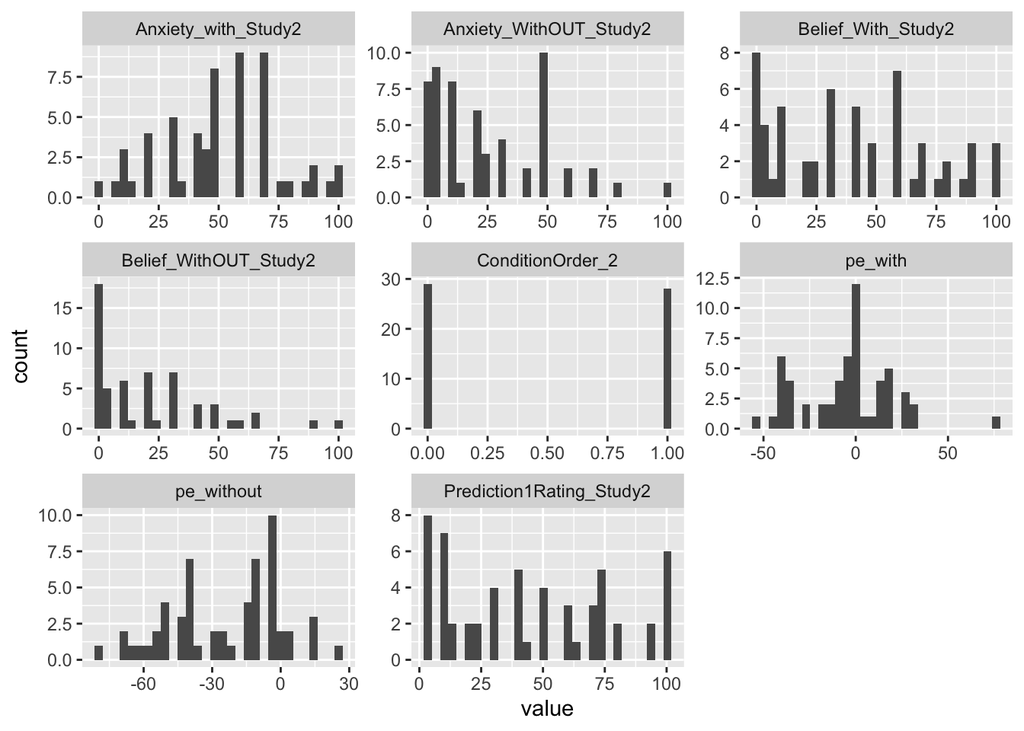

There is a clear shift through the experimental manipulation in both anxiety and belief, as well as PE. Interestingly, predictions follow a nearly bimodal distribution, possibly influenced by the group distributions (high vs low SoPh)

**I am creating a more principled long dataset to test our hypotheses in regression**

```r
anxiety <- el_soph_exp_pe  %>%
 dplyr:: select(ID, LSAS_St2_T,  Anxiety_with_Study2,Prediction1Rating_Study2, Anxiety_WithOUT_Study2)
anxiety <- anxiety %>%
  pivot_longer(
    cols = starts_with("Anx"),
    names_to = "condition",
    names_prefix = "anx",
    values_to = "anx_value",
    values_drop_na = TRUE
  )

pe <- el_soph_exp_pe  %>%
 dplyr:: select(ID, pe_with, pe_without)
pe <- pe %>%
  pivot_longer(
    cols = starts_with("pe"),
    names_to = "condition",
    names_prefix = "pe",
    values_to = "pe_value",
    values_drop_na = TRUE
  )

pe_anx_merged <- cbind(anxiety, pe)

belief <- el_soph_exp_pe  %>%
 dplyr:: select(ID, Belief_With_Study2, Belief_WithOUT_Study2 )
belief <- belief %>%
  pivot_longer(
    cols = starts_with("Belief"),
    names_to = "condition",
    names_prefix = "belief",
    values_to = "belief_value",
    values_drop_na = TRUE
  )

pe_anx_merged <- cbind(pe_anx_merged, belief)
pe_anx_merged <-pe_anx_merged [,c(-4,-6, -9, -10)]
pe_anx_merged <- pe_anx_merged %>%
rename(exp_value = Prediction1Rating_Study2)
```

**Let’s plot anxiety change**

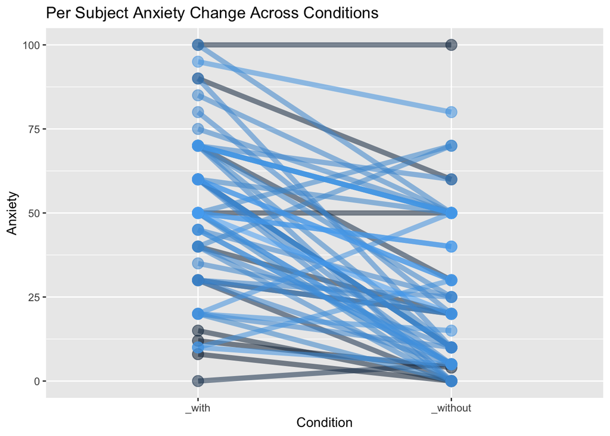

There is a clear change in anxiety across experimental conditions: it drops when safetey behaviours are dropped.

**Let’s plot belief change**

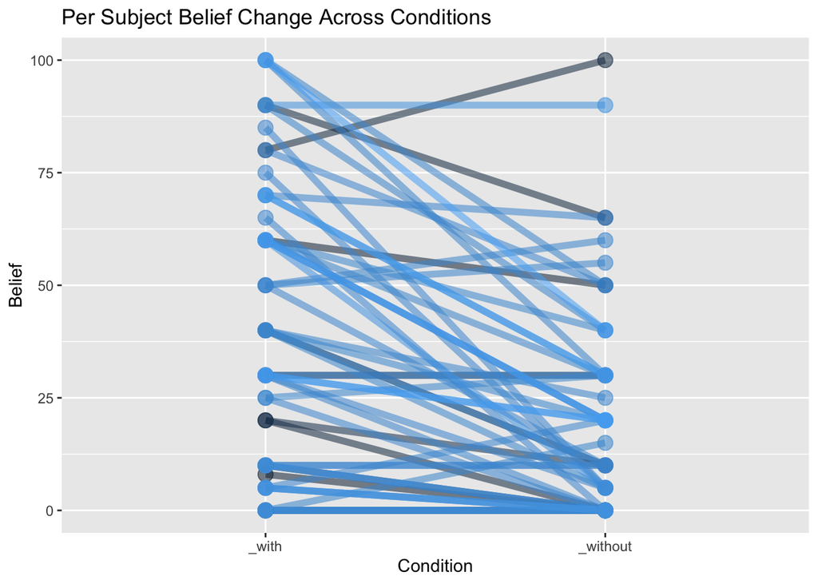

There is a clear change in belief across experimental conditions: it drops when safetey behaviours are dropped.

**Let’s plot pe change**

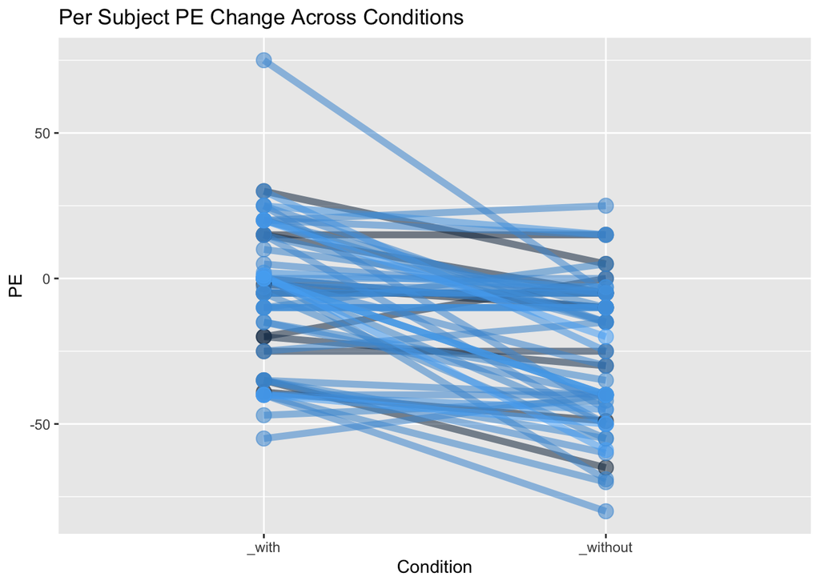

There is a clear change in pe across experimental conditions: it drops when safetey behaviours are dropped.

**Now let’s look at a correlation matrix of all the variables**

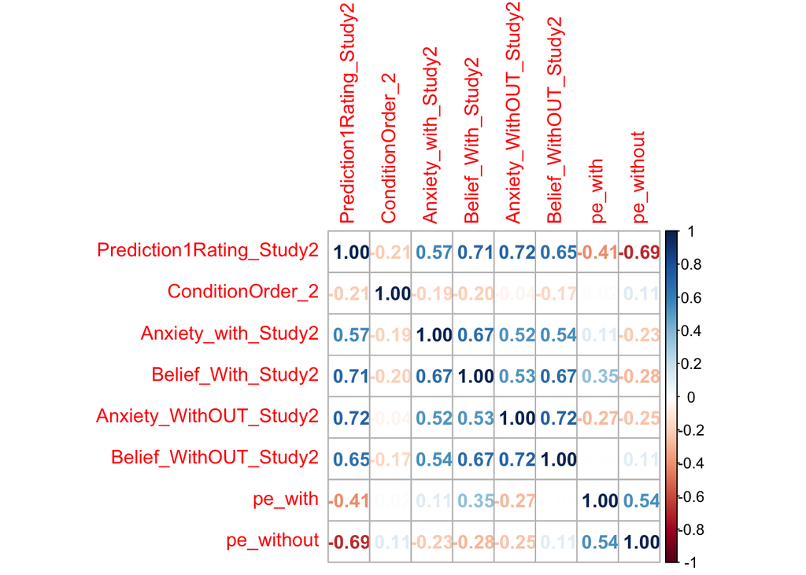

Belief and Anxiety are strongly correlated, perhaps unsurprisingly, but PE is not much. *Eleanor, what column are the stooges’ anxiety ratings? Do we have an end of session LSAS? I see lots of LSASs and MFQs there–are they related to St2?

**Now let’s test formally that pe differs by condition to which subjects were randomised to**

```r
t_test_for_pe <- t.test(el_soph_exp_pe$pe_with , el_soph_exp_pe$pe_without, paired = TRUE, alternative = "two.sided")
t_test_for_pe
```

```
##
##  Paired t-test
##
## data:  el_soph_exp_pe$pe_with and el_soph_exp_pe$pe_without
## t = 6.19, df = 56, p-value = 7.448e-08
## alternative hypothesis: true difference in means is not equal to 0
## 95 percent confidence interval:
##  13.08843 25.61332
## sample estimates:
## mean of the differences
##                19.35088
```

It clearly does

**The effect size can then be derived as follows, according to Lakens**

```r
d_pe <- t_test_for_pe$statistic/sqrt(57)
print(as.numeric(d_pe))
```

```
## [1] 0.8198838
```

Which is a pretty decent effect size.

**Similarly, we can show that anxiety differs by the the condition to which participants were randomised to**

```r
t_test_for_anx <- t.test(el_soph_exp_pe$Anxiety_with_Study2 , el_soph_exp_pe$Anxiety_WithOUT_Study2, paired = TRUE, alternative = "two.sided")
t_test_for_anx
```

```
##
##  Paired t-test
##
## data:  el_soph_exp_pe$Anxiety_with_Study2 and el_soph_exp_pe$Anxiety_WithOUT_Study2
## t = 7.9258, df = 56, p-value = 1.024e-10
## alternative hypothesis: true difference in means is not equal to 0
## 95 percent confidence interval:
##  18.69436 31.34072
## sample estimates:
## mean of the differences
##                25.01754
```

**For which the effect size can be estimated as above**

```r
d_anx <- t_test_for_anx$statistic/sqrt(57)
print(as.numeric(d_anx))
```

```
## [1] 1.049796
```

Which is also very big

**And finally, let’s show the direct relationship between PE and anxiety in the two different conditions**

**Let’s now plot the relationship between PE and anxiety outcome across conditions**

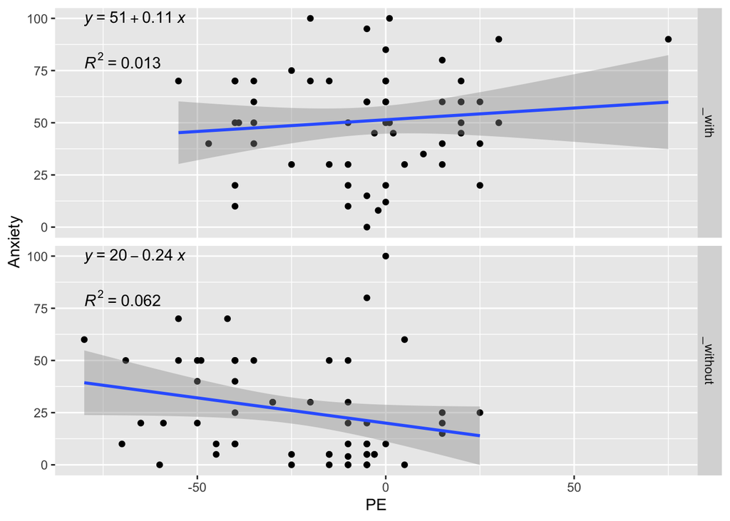

```r
library(ggpubr)

pe_anx_merged %>%
  ggplot(aes(x = pe_value, y = anx_value)) +
  geom_point()+
  labs(x= "PE", y="Anxiety")+
  geom_smooth(method = lm) +
  facet_grid(rows = vars(condition)) +
    stat_regline_equation(label.y = 100, aes(label = ..eq.label..)) +
  stat_regline_equation(label.y = 80, aes(label = ..rr.label..))
```

This clearly shows that there is no relationship between PE and anxiety.

**Let’s look at how PE relates to anxiety broken down by conditions**

```r
pe_anx_merged %>%
  group_by(condition) %>%
summarize(cor_coef= stats:: cor.test(anx_value, pe_value)$estimate,
          p_value = stats:: cor.test(anx_value, pe_value)$p.value)
```

```
## # A tibble: 2 × 3
##   condition cor_coef p_value
##   <chr>        <dbl>   <dbl>
## 1 _with        0.112  0.407
## 2 _without    -0.249  0.0619
```

Which is confirmed here

**The findings from the last two regression models and the correlation matrix further up suggest to me that PE is not associated with anxiety ratings during the conversation. The pedestrian analyses above suggest not**

**I am going to try it with mediation–these models do not take dependence into account, but this should if anything inflate the p-values because it underestimates the SEs**

**Trying it with a standard mediation package in R**

```
##
## Causal Mediation Analysis
##
## Quasi-Bayesian Confidence Intervals
##
##                Estimate 95% CI Lower 95% CI Upper p-value
## ACME             1.3032      -2.2620         4.87    0.42
## ADE            -26.1213     -35.1431       -17.31  <2e-16 ***
## Total Effect   -24.8181     -33.0434       -16.55  <2e-16 ***
## Prop. Mediated  -0.0441      -0.2267         0.09    0.42
## ---
## Signif. codes:  0 '***' 0.001 '**' 0.01 '*' 0.05 '.' 0.1 ' ' 1
##
## Sample Size Used: 114
##
##
## Simulations: 500
```

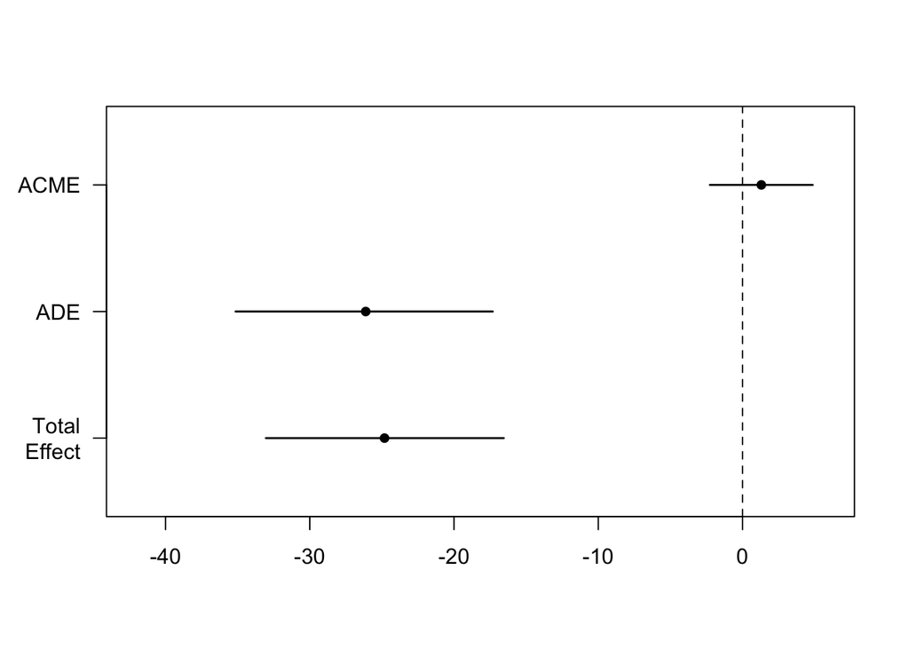

This result suggests no mediation

**Trying it also with SEM**

```r
sem_model = '
  pe_value ~ a*condition
  anx_value ~ c*condition +  b*pe_value

  # direct effect
  direct := c

  # indirect effect
  indirect := a*b

  # total effect
  total := c + (a*b)
'

model_sem = sem(sem_model, data=pe_anx_merged, se='boot', bootstrap=500)
summary(model_sem, rsq=T)
```

```
## lavaan 0.6-11 ended normally after 1 iterations
##
##   Estimator                                         ML
##   Optimization method                           NLMINB
##   Number of model parameters                         5
##
##   Number of observations                           114
##
## Model Test User Model:
##
##   Test statistic                                 0.000
##   Degrees of freedom                                 0
##
## Parameter Estimates:
##
##   Standard errors                            Bootstrap
##   Number of requested bootstrap draws              500
##   Number of successful bootstrap draws             500
##
## Regressions:
##                    Estimate  Std.Err  z-value  P(>|z|)
##   pe_value ~
##     condition  (a)  -19.351    4.410   -4.388    0.000
##   anx_value ~
##     condition  (c)  -26.315    4.986   -5.278    0.000
##     pe_value   (b)   -0.067    0.102   -0.660    0.509
##
## Variances:
##                    Estimate  Std.Err  z-value  P(>|z|)
##    .pe_value        597.814   76.565    7.808    0.000
##    .anx_value       580.323   69.911    8.301    0.000
##
## R-Square:
##                    Estimate
##     pe_value          0.135
##     anx_value         0.215
##
## Defined Parameters:
##                    Estimate  Std.Err  z-value  P(>|z|)
##     direct          -26.315    4.991   -5.272    0.000
##     indirect          1.297    2.026    0.640    0.522
##     total           -25.018    4.656   -5.373    0.000
```

This result confirms that there is no mediation.

**More generally, it seems that the correlation between anxiety and pe is minimal across conditions**

```r
cor.test(pe_anx_merged$anx_value, pe_anx_merged$pe_value )
```

```
##
##  Pearson's product-moment correlation
##
## data:  pe_anx_merged$anx_value and pe_anx_merged$pe_value
## t = 1.206, df = 112, p-value = 0.2304
## alternative hypothesis: true correlation is not equal to 0
## 95 percent confidence interval:
##  -0.07219872  0.29107331
## sample estimates:
##       cor
## 0.1132195
```

**Check: just in case I have mis-construed the pe variable, I have also used the variable foundin Eleanor’s database and correlated with mine

```r
el_soph_exp_pe_cor <- el_soph_exp_pe %>%
 dplyr:: select(c(PredErrorWITH ,PredErrorWITHOUT, pe_with, pe_without))%>%
  correlate()
```

```
##
## Correlation method: 'pearson'
## Missing treated using: 'pairwise.complete.obs'
```

```r
el_soph_exp_pe_cor
```

```
## # A tibble: 4 × 5
##   term             PredErrorWITH PredErrorWITHOUT pe_with pe_without
##   <chr>                    <dbl>            <dbl>   <dbl>      <dbl>
## 1 PredErrorWITH           NA                0.542   1          0.542
## 2 PredErrorWITHOUT         0.542           NA       0.542      1
## 3 pe_with                  1                0.542  NA          0.542
## 4 pe_without               0.542            1       0.542     NA
```

As can be seen Eleanor’s and my pe variables are perfectly correlated.

**Now let’s try the mediation steps above to see whether we get anything with belief**

**starting again using beliefs this time**

**Here is the relatinoship between anxiety and belief broken down by condition

```r
pe_anx_merged %>%
  group_by(condition) %>%
summarize(cor_coef= stats:: cor.test(anx_value, belief_value)$estimate,
          p_value = stats:: cor.test(anx_value, belief_value)$p.value)
```

```
## # A tibble: 2 × 3
##   condition cor_coef  p_value
##   <chr>        <dbl>    <dbl>
## 1 _with        0.674 9.25e- 9
## 2 _without     0.724 1.95e-10
```

```r
lm_anx_pe_with <- lm(Anxiety_with_Study2 ~ Belief_With_Study2 , data = el_soph_exp_pe)
summary(lm_anx_pe_with)
```

```
##
## Call:
## lm(formula = Anxiety_with_Study2 ~ Belief_With_Study2, data = el_soph_exp_pe)
##
## Residuals:
##     Min      1Q  Median      3Q     Max
## -32.217 -15.166  -1.305  15.625  37.448
##
## Coefficients:
##                    Estimate Std. Error t value Pr(>|t|)
## (Intercept)        29.93805    3.93528   7.608 3.81e-10 ***
## Belief_With_Study2  0.52279    0.07731   6.762 9.25e-09 ***
## ---
## Signif. codes:  0 '***' 0.001 '**' 0.01 '*' 0.05 '.' 0.1 ' ' 1
##
## Residual standard error: 18.34 on 55 degrees of freedom
## Multiple R-squared:  0.454,  Adjusted R-squared:  0.444
## F-statistic: 45.73 on 1 and 55 DF,  p-value: 9.246e-09
```

This clearly suggests a relationship

**Now let’s check the standard mediation model for beliefs, instead of PE**

```r
model_mediator <- lm(belief_value ~ condition , data = pe_anx_merged)
model_outcome  <- lm(anx_value ~ condition + belief_value, data = pe_anx_merged)

mediation_result <- mediate(
  model_mediator,
  model_outcome,
  sims = 500,
  treat = "condition",
  mediator = "belief_value"
)
summary(mediation_result)
```

```
##
## Causal Mediation Analysis
##
## Quasi-Bayesian Confidence Intervals
##
##                Estimate 95% CI Lower 95% CI Upper p-value
## ACME            -11.917      -18.845        -5.34  <2e-16 ***
## ADE             -13.759      -20.593        -6.86  <2e-16 ***
## Total Effect    -25.676      -34.820       -17.54  <2e-16 ***
## Prop. Mediated    0.464        0.257         0.69  <2e-16 ***
## ---
## Signif. codes:  0 '***' 0.001 '**' 0.01 '*' 0.05 '.' 0.1 ' ' 1
##
## Sample Size Used: 114
##
##
## Simulations: 500
```

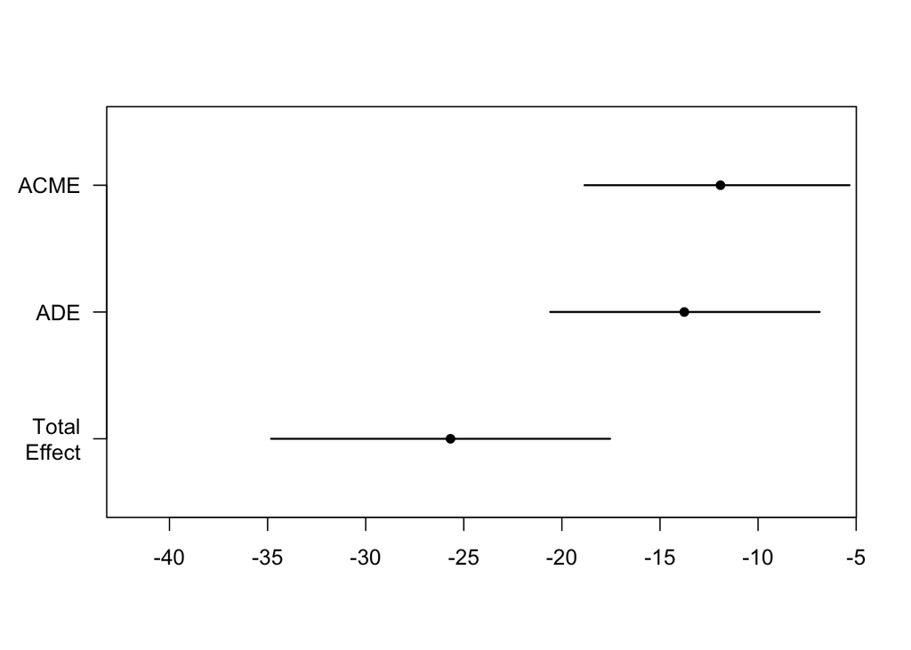

```r
plot(mediation_result)
```

and there is a clear mediation here

**And for confirmation, here is also the SEM mediation model for beliefs, instead of PE**

```r
sem_model = '
  belief_value ~ a*condition
  anx_value ~ c*condition +  b*belief_value

  # direct effect
  direct := c

  # indirect effect
  indirect := a*b

  # total effect
  total := c + (a*b)
'

model_sem = sem(sem_model, data=pe_anx_merged, se='boot', bootstrap=500)
summary(model_sem, rsq=T)
```

```
## lavaan 0.6-11 ended normally after 1 iterations
##
##   Estimator                                         ML
##   Optimization method                           NLMINB
##   Number of model parameters                         5
##
##   Number of observations                           114
##
## Model Test User Model:
##
##   Test statistic                                 0.000
##   Degrees of freedom                                 0
##
## Parameter Estimates:
##
##   Standard errors                            Bootstrap
##   Number of requested bootstrap draws              500
##   Number of successful bootstrap draws             500
##
## Regressions:
##                    Estimate  Std.Err  z-value  P(>|z|)
##   belief_value ~
##     condition  (a)  -19.351    5.297   -3.653    0.000
##   anx_value ~
##     condition  (c)  -13.427    3.771   -3.560    0.000
##     belief_val (b)    0.599    0.068    8.779    0.000
##
## Variances:
##                    Estimate  Std.Err  z-value  P(>|z|)
##    .belief_value    771.673   91.173    8.464    0.000
##    .anx_value       306.158   35.069    8.730    0.000
##
## R-Square:
##                    Estimate
##     belief_value      0.108
##     anx_value         0.586
##
## Defined Parameters:
##                    Estimate  Std.Err  z-value  P(>|z|)
##     direct          -13.427    3.775   -3.557    0.000
##     indirect        -11.591    3.341   -3.469    0.001
##     total           -25.018    4.814   -5.196    0.000
```

This too confirms it, but remember that the p-value estimates will be biased because of the clustering.

**Now let’s examine the properties of prediction, i.e. the *expectation as such as opposed to the PE*. First some correlations** **First, between anxiety and expectation**

```r
pe_anx_merged %>%
  group_by(condition) %>%
summarize(cor_coef= stats:: cor.test(anx_value, exp_value)$estimate,
          p_value = stats:: cor.test(anx_value, exp_value)$p.value)
```

```
## # A tibble: 2 × 3
##   condition cor_coef  p_value
##   <chr>        <dbl>    <dbl>
## 1 _with        0.572 3.32e- 6
## 2 _without     0.720 2.77e-10
```

There is a fairly strong correlation with anxiety across both conditions

**Let’s now plot the relationship between expectation and anxiety outcome across conditions**

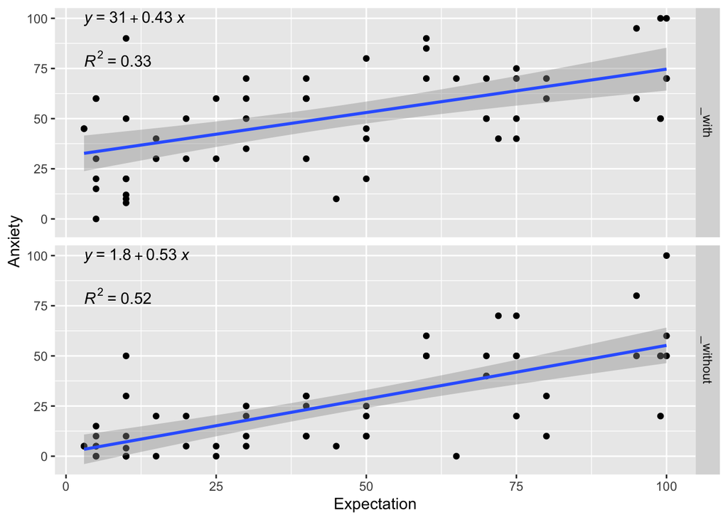

```r
library(ggpubr)

pe_anx_merged %>%
  ggplot(aes(x = exp_value, y = anx_value)) +
  geom_point()+
  labs(x= "Expectation", y="Anxiety")+
  geom_smooth(method = lm) +
  facet_grid(rows = vars(condition)) +
    stat_regline_equation(label.y = 100, aes(label = ..eq.label..)) +
  stat_regline_equation(label.y = 80, aes(label = ..rr.label..))
```

This indicates a consistent relationship across conditions, perhaps with a stronger one for the without.

**Now let’s examine whether expectation moderates outcomes in lme for anxiety (no strong indication from the plots)**

```r
mod_interaction_anxiety <- lmer(anx_value ~ exp_value*condition + (1|ID), data = pe_anx_merged)
summary(mod_interaction_anxiety )
```

```
## Linear mixed model fit by REML. t-tests use Satterthwaite's method [
## lmerModLmerTest]
## Formula: anx_value ~ exp_value * condition + (1 | ID)
##    Data: pe_anx_merged
##
## REML criterion at convergence: 984.5
##
## Scaled residuals:
##      Min       1Q   Median       3Q      Max
## -1.92347 -0.63485 -0.02375  0.57839  2.68257
##
## Random effects:
##  Groups   Name        Variance Std.Dev.
##  ID       (Intercept)  66.25    8.139
##  Residual             283.57   16.840
## Number of obs: 114, groups:  ID, 57
##
## Fixed effects:
##                              Estimate Std. Error        df t value Pr(>|t|)
## (Intercept)                  31.40860    4.25408 106.19169   7.383 3.64e-11 ***
## exp_value                     0.43264    0.07685 106.19169   5.630 1.49e-07 ***
## condition_without           -29.58364    5.41665  55.00000  -5.462 1.17e-06 ***
## exp_value:condition_without   0.10147    0.09785  55.00000   1.037    0.304
## ---
## Signif. codes:  0 '***' 0.001 '**' 0.01 '*' 0.05 '.' 0.1 ' ' 1
##
## Correlation of Fixed Effects:
##             (Intr) exp_vl cndtn_
## exp_value   -0.813
## condtn_wtht -0.637  0.518
## exp_vl:cnd_  0.518 -0.637 -0.813
```

The interaction seems very weak.

**Perhaps a simple additive model will be just fine, where expectation simply predicts**

```r
mod_additive_anxiety <- lmer(anx_value ~ exp_value + condition + (1|ID), data = pe_anx_merged)
anova(mod_additive_anxiety ,mod_interaction_anxiety )
```

```
## refitting model(s) with ML (instead of REML)
```

```
## Data: pe_anx_merged
## Models:
## mod_additive_anxiety: anx_value ~ exp_value + condition + (1 | ID)
## mod_interaction_anxiety: anx_value ~ exp_value * condition + (1 | ID)
##                         npar    AIC    BIC  logLik deviance  Chisq Df
## mod_additive_anxiety       5 996.21 1009.9 -493.11   986.21
## mod_interaction_anxiety    6 997.11 1013.5 -492.56   985.11 1.1036  1
##                         Pr(>Chisq)
## mod_additive_anxiety
## mod_interaction_anxiety     0.2935
```

The evidence of moderation seems extremely weak to me.

**Now compare to a simple model with just condition**

```r
mod_simple_anxiety <- lmer(anx_value ~ condition + (1|ID), data = pe_anx_merged)
anova(mod_simple_anxiety, mod_additive_anxiety)
```

```
## refitting model(s) with ML (instead of REML)
```

```
## Data: pe_anx_merged
## Models:
## mod_simple_anxiety: anx_value ~ condition + (1 | ID)
## mod_additive_anxiety: anx_value ~ exp_value + condition + (1 | ID)
##                      npar     AIC    BIC  logLik deviance  Chisq Df Pr(>Chisq)
## mod_simple_anxiety      4 1039.40 1050.3 -515.70  1031.40
## mod_additive_anxiety    5  996.21 1009.9 -493.11   986.21 45.188  1   1.79e-11
##
## mod_simple_anxiety
## mod_additive_anxiety ***
## ---
## Signif. codes:  0 '***' 0.001 '**' 0.01 '*' 0.05 '.' 0.1 ' ' 1
```

The additive model seems clearly superior. People’s expectation seems to play an important role in anxiety outcome.

**But is it just severity**

```r
mod_additive_anxiety <- lmer(anx_value ~ exp_value + condition +  (1|ID), data = pe_anx_merged)
summary(mod_additive_anxiety)
```

```
## Linear mixed model fit by REML. t-tests use Satterthwaite's method [
## lmerModLmerTest]
## Formula: anx_value ~ exp_value + condition + (1 | ID)
##    Data: pe_anx_merged
##
## REML criterion at convergence: 982.8
##
## Scaled residuals:
##      Min       1Q   Median       3Q      Max
## -1.86267 -0.65619 -0.06211  0.57638  2.78770
##
## Random effects:
##  Groups   Name        Variance Std.Dev.
##  ID       (Intercept)  66.06    8.128
##  Residual             283.96   16.851
## Number of obs: 114, groups:  ID, 57
##
## Fixed effects:
##                    Estimate Std. Error        df t value Pr(>|t|)
## (Intercept)        29.12555    3.64047  79.23637   8.001 8.54e-12 ***
## exp_value           0.48337    0.05926  55.00000   8.156 4.86e-11 ***
## condition_without -25.01754    3.15648  56.00000  -7.926 1.02e-10 ***
## ---
## Signif. codes:  0 '***' 0.001 '**' 0.01 '*' 0.05 '.' 0.1 ' ' 1
##
## Correlation of Fixed Effects:
##             (Intr) exp_vl
## exp_value   -0.733
## condtn_wtht -0.434  0.000
```

```r
mod_additive_anxiety_lsas <- lmer(anx_value ~ exp_value + condition + LSAS_St2_T + (1|ID), data = pe_anx_merged)
summary(mod_additive_anxiety_lsas)
```

```
## Linear mixed model fit by REML. t-tests use Satterthwaite's method [
## lmerModLmerTest]
## Formula: anx_value ~ exp_value + condition + LSAS_St2_T + (1 | ID)
##    Data: pe_anx_merged
##
## REML criterion at convergence: 956.6
##
## Scaled residuals:
##      Min       1Q   Median       3Q      Max
## -1.94428 -0.57827 -0.06127  0.65793  3.05042
##
## Random effects:
##  Groups   Name        Variance Std.Dev.
##  ID       (Intercept)  23.73    4.871
##  Residual             287.03   16.942
## Number of obs: 112, groups:  ID, 56
##
## Fixed effects:
##                    Estimate Std. Error        df t value Pr(>|t|)
## (Intercept)        29.61100    3.38383  81.44670   8.751 2.37e-13 ***
## exp_value           0.20694    0.08829  53.00000   2.344 0.022863 *
## condition_without -25.28571    3.20174  54.99999  -7.898 1.28e-10 ***
## LSAS_St2_T          0.29092    0.07412  53.00000   3.925 0.000252 ***
## ---
## Signif. codes:  0 '***' 0.001 '**' 0.01 '*' 0.05 '.' 0.1 ' ' 1
##
## Correlation of Fixed Effects:
##             (Intr) exp_vl cndtn_
## exp_value   -0.452
## condtn_wtht -0.473  0.000
## LSAS_St2_T   0.023 -0.796  0.000
```

**Now let’s examine the relationship between *belief and prediction***

```r
pe_anx_merged %>%
  group_by(condition) %>%
summarize(cor_coef= stats:: cor.test(belief_value, exp_value)$estimate,
          p_value = stats:: cor.test(belief_value, exp_value)$p.value)
```

```
## # A tibble: 2 × 3
##   condition cor_coef  p_value
##   <chr>        <dbl>    <dbl>
## 1 _with        0.709 6.74e-10
## 2 _without     0.651 4.21e- 8
```

There is a strong correlation with belief across both conditions

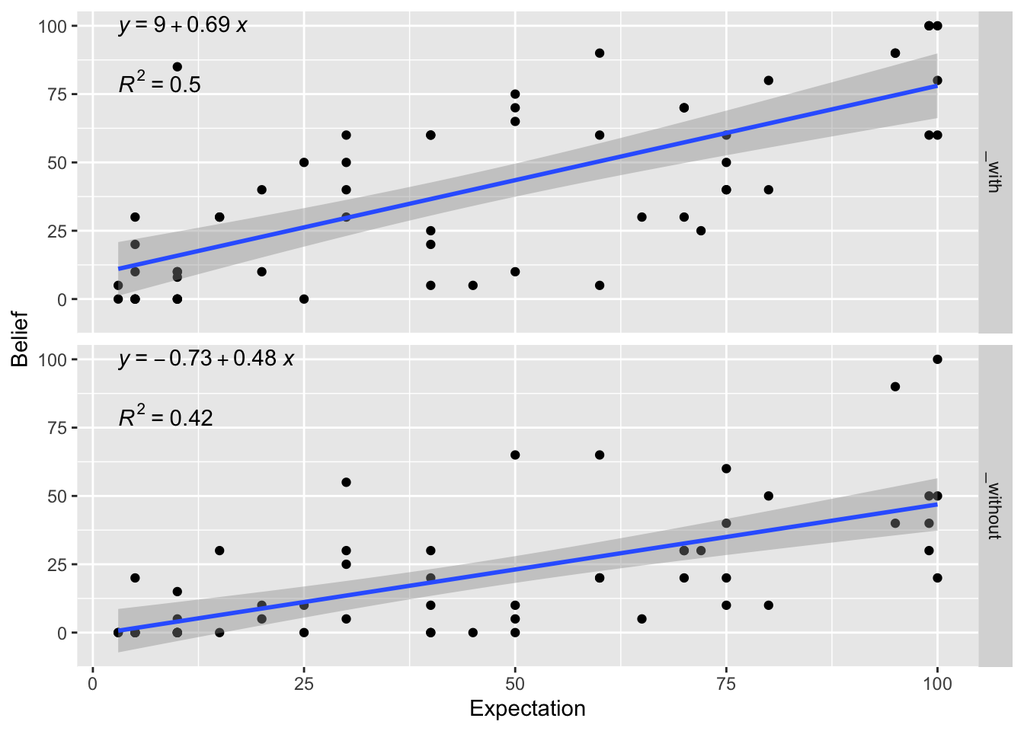

```r
library(ggpubr)

pe_anx_merged %>%
  ggplot(aes(x = exp_value, y = belief_value)) +
  geom_point()+
  labs(x= "Expectation", y="Belief")+
  geom_smooth(method = lm) +
  facet_grid(rows = vars(condition)) +
    stat_regline_equation(label.y = 100, aes(label = ..eq.label..)) +
  stat_regline_equation(label.y = 80, aes(label = ..rr.label..))
```

**Now let’s examine whether expectation moderates outcomes in lme for beliefs**

```r
mod_interaction_belief <- lmer(belief_value ~ exp_value*condition + (1|ID), data = pe_anx_merged)
summary(mod_interaction_belief )
```

```
## Linear mixed model fit by REML. t-tests use Satterthwaite's method [
## lmerModLmerTest]
## Formula: belief_value ~ exp_value * condition + (1 | ID)
##    Data: pe_anx_merged
##
## REML criterion at convergence: 998
##
## Scaled residuals:
##      Min       1Q   Median       3Q      Max
## -1.90362 -0.57817 -0.09038  0.47097  3.08702
##
## Random effects:
##  Groups   Name        Variance Std.Dev.
##  ID       (Intercept) 161.7    12.72
##  Residual             258.8    16.09
## Number of obs: 114, groups:  ID, 57
##
## Fixed effects:
##                             Estimate Std. Error       df t value Pr(>|t|)
## (Intercept)                  8.95986    4.66397 95.83054   1.921   0.0577 .
## exp_value                    0.69095    0.08426 95.83054   8.201 1.08e-12 ***
## condition_without           -9.69445    5.17459 55.00000  -1.873   0.0663 .
## exp_value:condition_without -0.21459    0.09348 55.00000  -2.296   0.0255 *
## ---
## Signif. codes:  0 '***' 0.001 '**' 0.01 '*' 0.05 '.' 0.1 ' ' 1
##
## Correlation of Fixed Effects:
##             (Intr) exp_vl cndtn_
## exp_value   -0.813
## condtn_wtht -0.555  0.451
## exp_vl:cnd_  0.451 -0.555 -0.813
```

**Perhaps a simple additive model will be just fine, where expectation simply predicts**

```r
mod_additive_belief <- lmer(belief_value ~ exp_value + condition + (1|ID), data = pe_anx_merged)
anova(mod_additive_belief ,mod_interaction_belief )
```

```
## refitting model(s) with ML (instead of REML)
```

```
## Data: pe_anx_merged
## Models:
## mod_additive_belief: belief_value ~ exp_value + condition + (1 | ID)
## mod_interaction_belief: belief_value ~ exp_value * condition + (1 | ID)
##                        npar    AIC    BIC  logLik deviance Chisq Df Pr(>Chisq)
## mod_additive_belief       5 1014.3 1027.9 -502.13  1004.26
## mod_interaction_belief    6 1011.0 1027.5 -499.52   999.05 5.215  1    0.02239
##
## mod_additive_belief
## mod_interaction_belief *
## ---
## Signif. codes:  0 '***' 0.001 '**' 0.01 '*' 0.05 '.' 0.1 ' ' 1
```

**Now compare to a simple model with just condition**

```r
mod_simple_belief <- lmer(belief_value ~ condition + (1|ID), data = pe_anx_merged)
anova(mod_simple_belief, mod_additive_belief)
```

```
## refitting model(s) with ML (instead of REML)
```

```
## Data: pe_anx_merged
## Models:
## mod_simple_belief: belief_value ~ condition + (1 | ID)
## mod_additive_belief: belief_value ~ exp_value + condition + (1 | ID)
##                     npar    AIC    BIC  logLik deviance  Chisq Df Pr(>Chisq)
## mod_simple_belief      4 1058.7 1069.7 -525.37   1050.7
## mod_additive_belief    5 1014.3 1027.9 -502.13   1004.3 46.483  1  9.239e-12
##
## mod_simple_belief
## mod_additive_belief ***
## ---
## Signif. codes:  0 '***' 0.001 '**' 0.01 '*' 0.05 '.' 0.1 ' ' 1
```

## Conclusions

##Thoughts about the grant

I think that the manipulation in Eleanor’s experiments are really powerful and I believe that we could make the most of them to be impactful with our grant application. Here are the main thoughts

1. Social Anxiety works really well as a treatment. This satisfies Wellcome’s condition of having something that is efficacious and therefore worth understanding its mechanism of action.
2. Eleanor’s experimental manipulation (and similar ones in adults I presume) are a powerful demonstration of the active ingredient that is self-focused attention, which is extremely important. It does not tell us what the responsible mechanism is for that active ingredient, which is part of what the point of this grant would be.
3. The above allow us to use and expand the experiment to test what the mechanisms are that underlie the effects of diverting self-focused attention. Because we have a good experimental set up (that we can further tweak), we shouldn’t need to run new case series. We could establish this using the experimental set up, to which we bring interoception, MEG etc to bear upon.
4. I think that it would be great if we tried to create a similar experimental set up as above for depression and also test mechanisms in a similar way. It would follow on nicely for two reasons: first, because depression and anxiety are cross-sectionally and longitudinally comorbid; second, because there is prior evidence suggesting that self-focused attention is a potential mechanism in depression. Ideally, we should build something that involves mood or hedonic response and demonstrate the influence of self-focused attention (and any mechanisms we find) on it. One idea is that the mechanism that makes you socially anxious is the same as the one that makes you not appreciate/dislike something enjoyable.
5. By doing so, we will have a) isolated an active ingredient; b) shown its mechanisms; c) used it to make progress in another illness, depression, which is arguably more difficult. We could do all this without the need to do patient series, involve IAPT etc.
6. You may ask where all this leaves prediction errors. We could and should still include this as a mechanism but it won’t be the sole candidate, but rather one of many. This would involve changing the title of the application too.

**ADDITIONAL ANALYSES, TO BE OPTIMISED. I ran into problems with running within group mediation analyses as below, need to figure out the problems. I have commented out things for the moment**